# Investigacion Sobre las Universidades y sus Egresados

INTEGRANTES: Camila Gonzalez, Luciana Parallela, Camila Rondon, Mauricio Medina, Lucas Colosimo

Recolección De Datos y Análisis Primario de la Información

### Introducción

Este trabajo utiliza datos del **Ministerio de Educación de la Nación Argentina**, extraídos de los Anuarios de Estadísticas Universitarias, y de una base complementaria proveniente de la **Encuesta sobre Condiciones de Ingreso a la Universidad (ECIU)**. Los datasets incluyen información sobre **ingresantes, reinscriptos y egresados** en universidades públicas y privadas del país, desagregada por *carrera, área disciplinar, género, edad, modalidad de estudio y situación laboral*. Estas fuentes permiten analizar los factores que influyen en la *tasa de egreso universitaria*, como el tipo de institución, la disciplina académica, y las condiciones socioeconómicas de los estudiantes

## Definición de los objetivos del analisis

La *problemática* que hemos elegido para el presente trabajo se basa en los factores que hacen que haya menor o mayor tasa de egresados en las universidades de Buenos Aires. En base a esta problemática y a partir de los data sets seleccionados y a su respectivo análisis, hemos elegido los siguientes factores a analizar:

- Cuál es la diferencia en cantidad de graduados en instituciones públicas o privadas.
- Cómo varía la cantidad de egresados s/ área disciplinar (Área de ingeniería tiene más egresados que en otras áreas). (Gráfico de torta o barras: eje x: área disciplinar, eje y: cantidad de egresados)
- Carreras que tienen mmayor cantidad de egresados.
- Cómo varía la cantidad de graduados según su género.

## Análisis exploratorio

Hemos formulado las siguientes preguntas claves que iremos respondiendo a través del trabajo, estas nos permitirán tener un buen panoráma de la situación de los egresados.

- ¿Qué carreras tienen mayor cantidad de egresados?
- ¿Cómo varía la cantidad de egresados por área disciplinar?
- ¿Existen diferencias significativas en la cantidad de egresados entre instituciones estatales y privadas ?
- ¿Cómo varió la cantidad de egresados totales en 2020, 2021 y 2023?
- ¿Cómo varió la cantidad de reinscriptos en Universidades Nacionales entre los años 2020, 2021 y 2023?
- ¿Hubo diferencias en la cantidad de egresados en Universidades Nacionales y Provinciales durante los años 2021 y 2023?
- ¿Qué año tiene mayor cantidad de reinscriptos?
- ¿Qué género tiene mayor cantidad de graduados, son más hombres o mujeres?
- ¿Cómo afecta en la cantidad de graduados el nivel de academico de los padres?
- ¿Qué diferencias existen en la cantidad de egresados entre modalidad virtual y presencial?

## Justificación de la elección de los datasets

El dataset de los “Anuarios Estadísticos” del sistema universitario es la fuente más adecuada para estudiar la evolución en diversas áreas, las causas de ello y diferencias en la tasa de egreso universitaria en Buenos Aires. Además la información es confiable porque es oficial, completa, accesible, comparable entre años, y centrada en variables directamente vinculadas al fenómeno de estudio.

Además, elegimos el dataset “Universidades – egresados” del proyecto Argentina en datos (Chequeado) porque ofrece información clara sobre cuántas personas lograron finalizar sus estudios universitarios en Argentina hasta el año 2020. Al estar organizado por institución y tipo de gestión, permite observar diferencias entre universidades y regiones del país. Es una herramienta valiosa para reflexionar sobre cómo se distribuyen las oportunidades de egreso, entendiendo que cada número representa una historia atravesada por contextos muy distintos.

### Cantidad de graduados según tipo de institución

Se analiza la **diferencia entre cantidad de graduados provenientes de universidades públicas y universidades privadas**, el objetivo es ver cuál tipo proporciona una mayor cantidad de graduados a nivel nacional, podremos ver estas diferencias representadas en el siguiente gráfico:

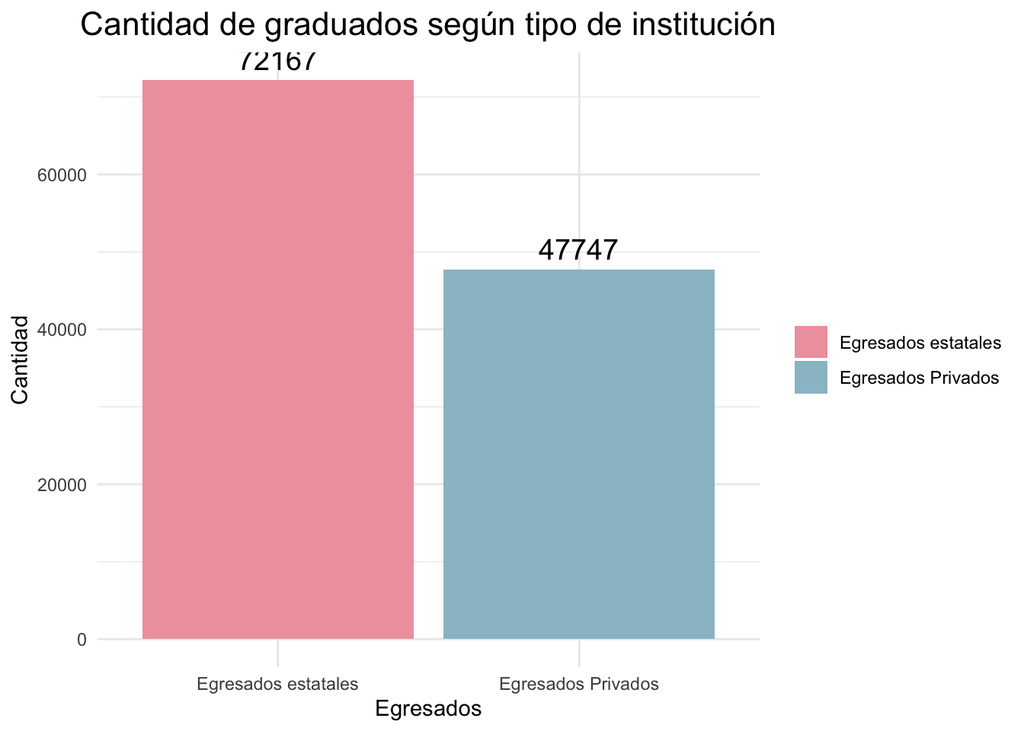

### TOP 10 CARRERAS CON MÁS GRADUADOS

Para ampliar la información, nos hemos preguntado ¿ cuáles son las carreras con más cantidad de graduados? para responder a ello, hemos escogido las **top 10 carreras con más cantidad de graduados** y hemos adicionado el total por cada una de ellas, esto es a nivel nacional, según datos del 2020.

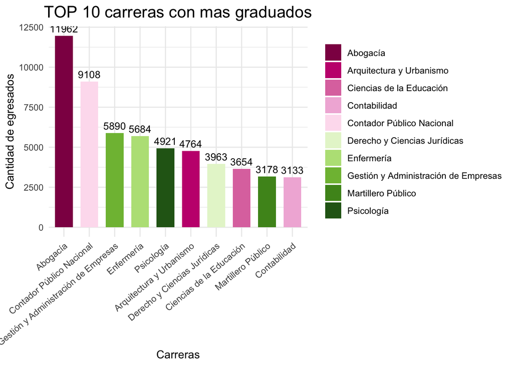

Como podemos ver, las carreras más elegidas son aquellas pertenecientes a las ciencias sociales y no a las ciencias exactas. La razón de esto se puede deber al bajo nivel matemático que poseen los estudiantes de la educación básica (primaria y secundaria). Según las Pruebas Aprender realizadas cada año, en el 2024, solo el 14,2% de los estudiantes alcanzó un nivel satisfactorio en matemáticas. Por lo tanto, no es sorpresa que las carreras de ciencias exactas no sean las más elegidas.

### RELACION GÉNERO - CANTIDAD DE GRADUADOS - TIPO DE INSTITUCIÓN

A continuación, realizamos un pequeño análisis respecto a la cantidad de egresados, su género (mujer u hombre) y el tipo de institucion de la cual proviene, ya sea universidad pública o privada. El objetivo de esto es ver si hay más egresados del género femenino o masculino. El primer gráfico que veremos será aquel proveniente de las **universidades públicas**:

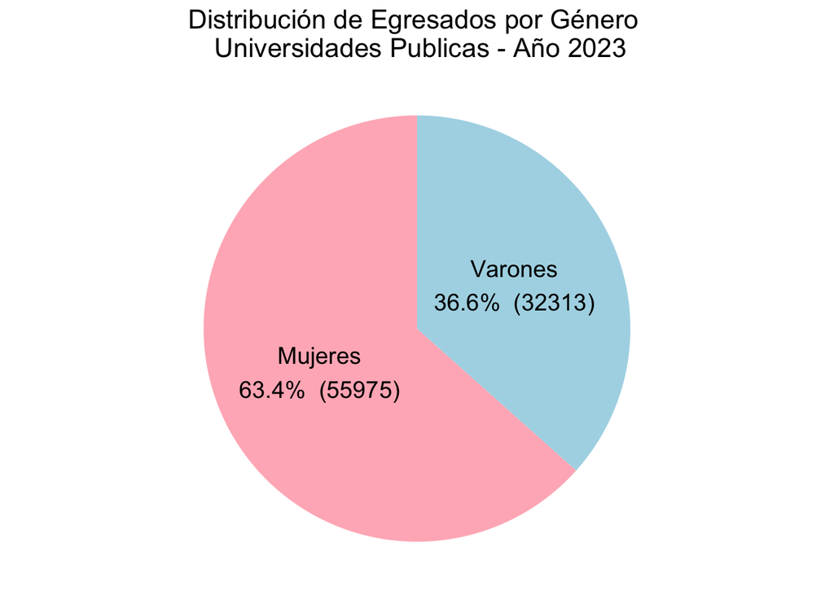

A continuación, el gráfico relacionado a las **universidades privadas**:

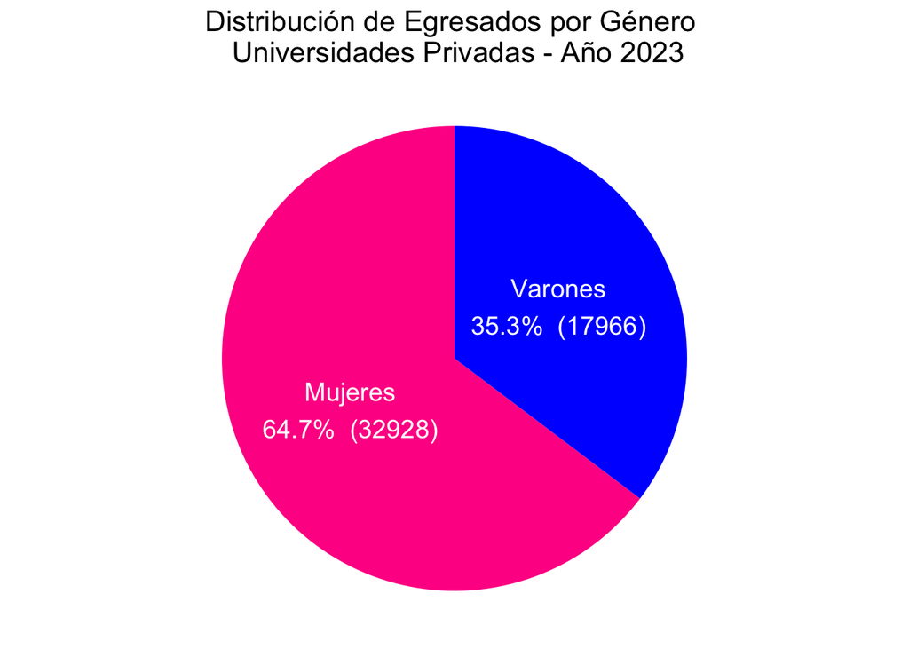

Por último, el siguiente gráfico es una pequeña **comparación de la cantidad de egresados según género y tipo de universidad**, como podemos apreciar, hay una mayor cantidad de graduadas mujeres, y este patrón se da tanto en universidades públicas como privadas:

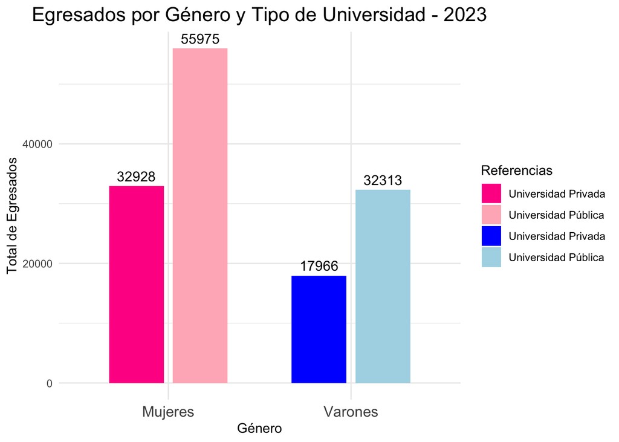

A partir de este gráfico, se aprecia que el comportamiento de la cantidad de graduados en relación al género se replica tanto en universidades privadas como públicas, en donde en ambas las mujeres predominan en la cantidad de egresados. Es interesante notar que la cantidad de egresadas mujeres provenientes de universidades privadas incluso supera a la cantidad de egresados varones provenientes de universidades públicas.

### ¿Cómo afecta la modalidad de estudio a la cantidad de egresados?

Hemos decidido analizar qué tipo de modalidad elegida por los estudiantes, siendo estas presencial o virtual, genera más cantidad de graduados. A partir de este análisis, hemos creado el siguiente gráfico comparativo:

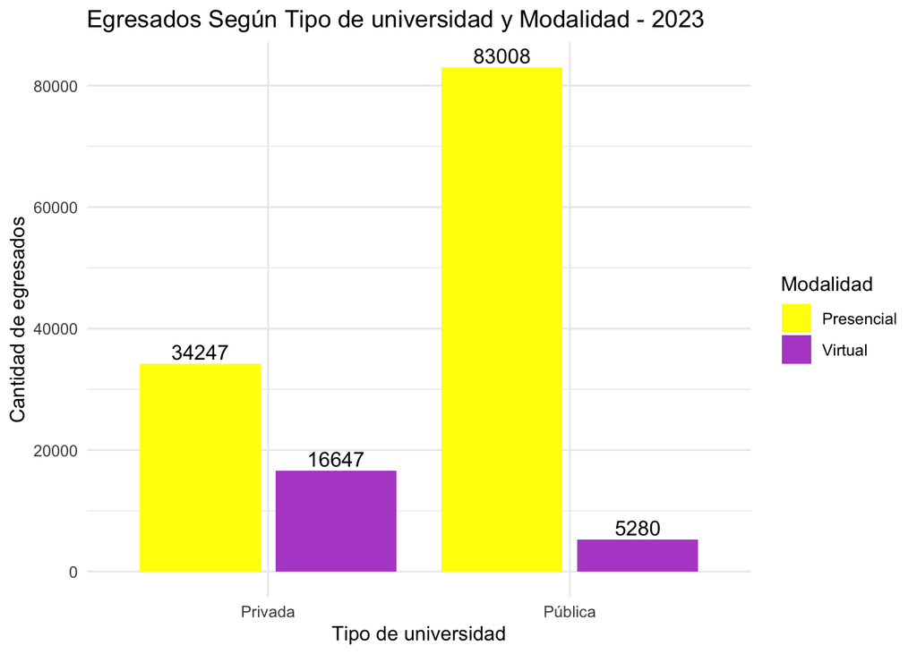

Como podemos ver, la virtualidad tiene un mayor impacto en las universidades privadas, en donde el 32,70% de su alumnado se egresa bajo esta modalidad, mientras que el 67,30% restante bajo la presencialidad. Sin embargo esto cambia drásticamente en las universidades públicas, donde solamente el 5,98% de los egresados es proveniente de la modalidad virtual, frente a un 94,02% restante, que eligió la presencialidad.

### Reinscriptos en universidades nacionales de gestión estatal

Se analiza la cantidad de reinscriptos en universidades **nacionales de gestión estatal** en los años **2020, 2021 y 2023** a partir de los anuarios estadísticos del sistema universitario.

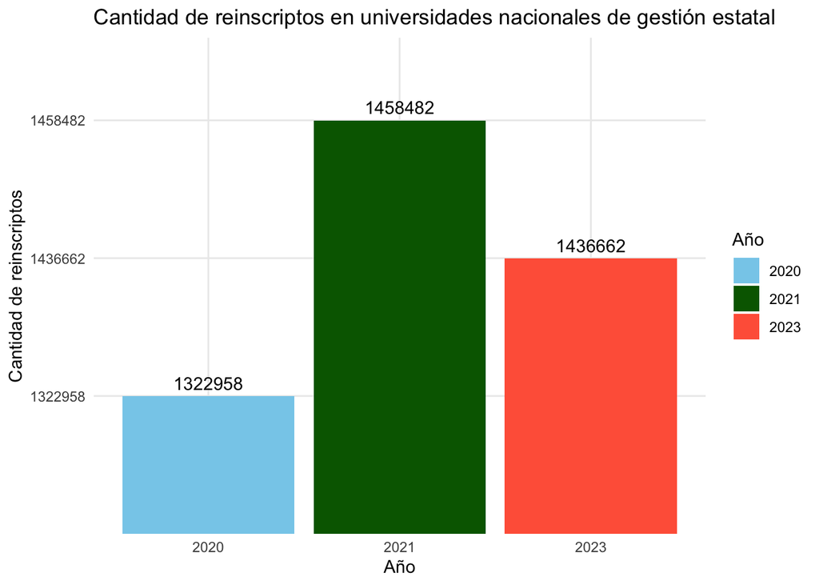

### Cantidad de egresados de Universidades Nacionales y Provinciales.

A partir del siguiente gráfico se hace un analisis de la cantidad de **egresados** de los **años 2021 y 2023** en Universidades tanto Nacionales como provinciales.

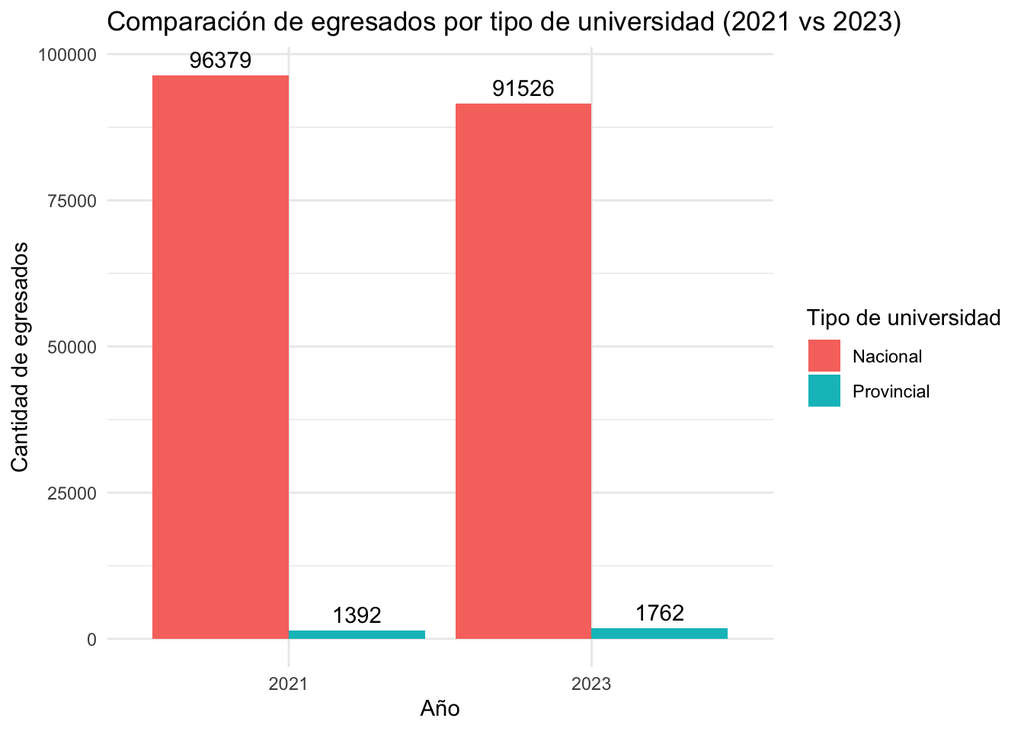

### ¿Cómo varía la cantidad de egresados por área disciplinar?

A partir de los datos recolectados, se puede observar que la cantidad de egresados varía bastante según el área disciplinar. Algunas áreas, como *Ciencias de la Salud: Medicina*, tienen una cantidad muy alta de egresados tanto en universidades estatales como privadas, lo que indica una fuerte presencia en el sistema educativo. En cambio, áreas como *Arquitectura y Diseño* o *Biología* tienen cifras más bajas.

También se nota que en ciertas disciplinas, como *Economía y Administración*, el número de egresados en la gestión privada es incluso mayor que en la estatal. Este tipo de diferencias nos ayudan a entender cómo se distribuyen los egresos en función del tipo de institución y del interés que despierta cada carrera.

| Rama y disciplina | Años | Total gestión estatal | Total gestión privada | Total |
| --- | --- | --- | --- | --- |
| Ciencias aplicadas: arquitectura y diseño | 2020, 2021, 2023 | 141, 122, 249 | 28, 32, 21 | 593 |
| ciencias basicas: Biología | 2020, 2021, 2023 | 392, 363, 478 | 13, 24, 23 | 1293 |
| Ciencias de la salud: Medicina | 2020, 2021, 2023 | 1656, 1762, 4968 | 658, 778, 747 | 10569 |
| Ciencias humanas: Educacion | 2020, 2021, 2023 | 1364, 930, 1160 | 289, 264, 316 | 4323 |
| Ciencias sociales: Economía y administración | 2020, 2021, 2023 | 638, 930, 1121 | 1653, 1429, 2056 | 7827 |

### Ojiva

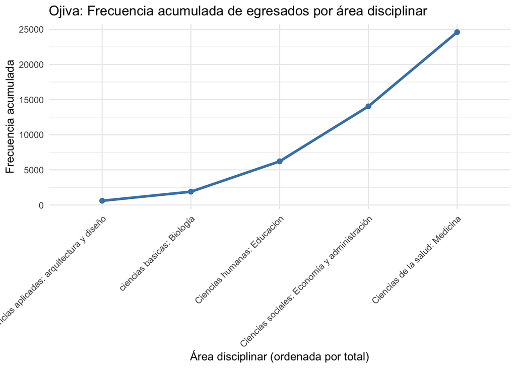

### Interpretación de la ojiva

La ojiva permite visualizar cómo se acumula el total de egresados por área disciplinar. Al ordenar las disciplinas de menor a mayor según su cantidad de egresados, observamos que unas pocas áreas concentran una gran parte del total acumulado. Por ejemplo, Ciencias de la Salud: Medicina aporta un incremento considerable en la curva, mientras que disciplinas como Arquitectura y Diseño o Biología generan un aumento más gradual.

Este tipo de representación es útil porque permite identificar rápidamente qué áreas tienen mayor peso en el total de egresados. Desde una perspectiva de Ciencia de Datos, la ojiva ayuda a detectar posibles desequilibrios en la distribución y podría servir como base para futuros análisis más profundos o recomendaciones educativas.

### 📊 Datos de egresados

```
##    Año  Total
## 1 2020 139182
## 2 2021 142826
## 3 2023 139182
```

### 📈 Cálculo de cambios entre años

```
##    Año  Total Cambio_Absoluto Cambio_Porcentaje
## 1 2020 139182              NA                NA
## 2 2021 142826            3644              2.62
## 3 2023 139182           -3644             -2.55
```

### 📊 Gráfico comparativo de egresados

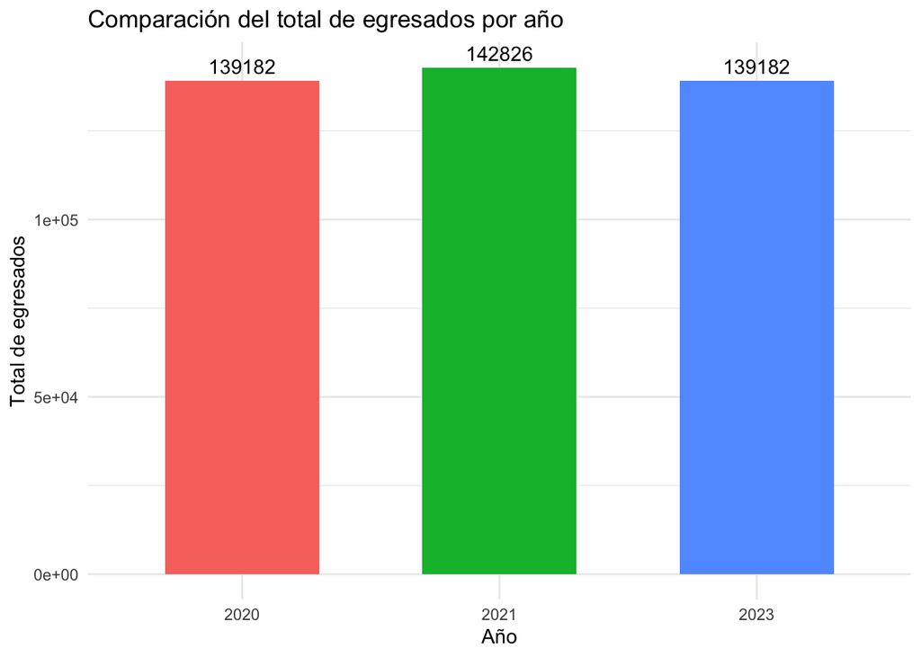

### Análisis del cambio en el número total de egresados

Entre 2020 y 2021, el total de egresados pasó de 139182 a 142826, lo que representa un aumento de 3644 egresados (2.62%).

Entre 2021 y 2023, el total de egresados pasó de 142826 a 139182, lo que representa una disminución de 3644 egresados (-2.55%).

En resumen, el gráfico de barras nos permite visualizar claramente que el año 2021 fue el de mayor cantidad de egresados, mientras que en 2020 y 2023 el número total fue exactamente el mismo. Esta oscilación puede reflejar variaciones en cohortes, políticas educativas o condiciones externas como la pandemia.

### ¿Cómo afecta a la cantidad de graduados el nivel academico de sus padres?

### 📊 Unimos los dos codigos para luego graficar la comparacion ver juntos ambos resultados

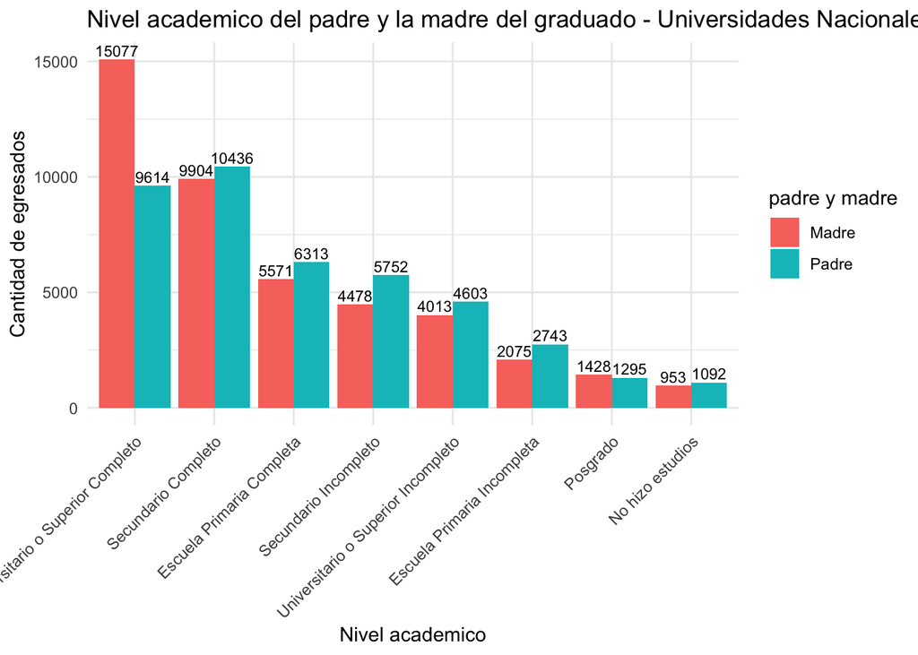

Como podemos observar en el grafico de barras el nivel de academico de los padres es crucial en la cantidad de graduados.